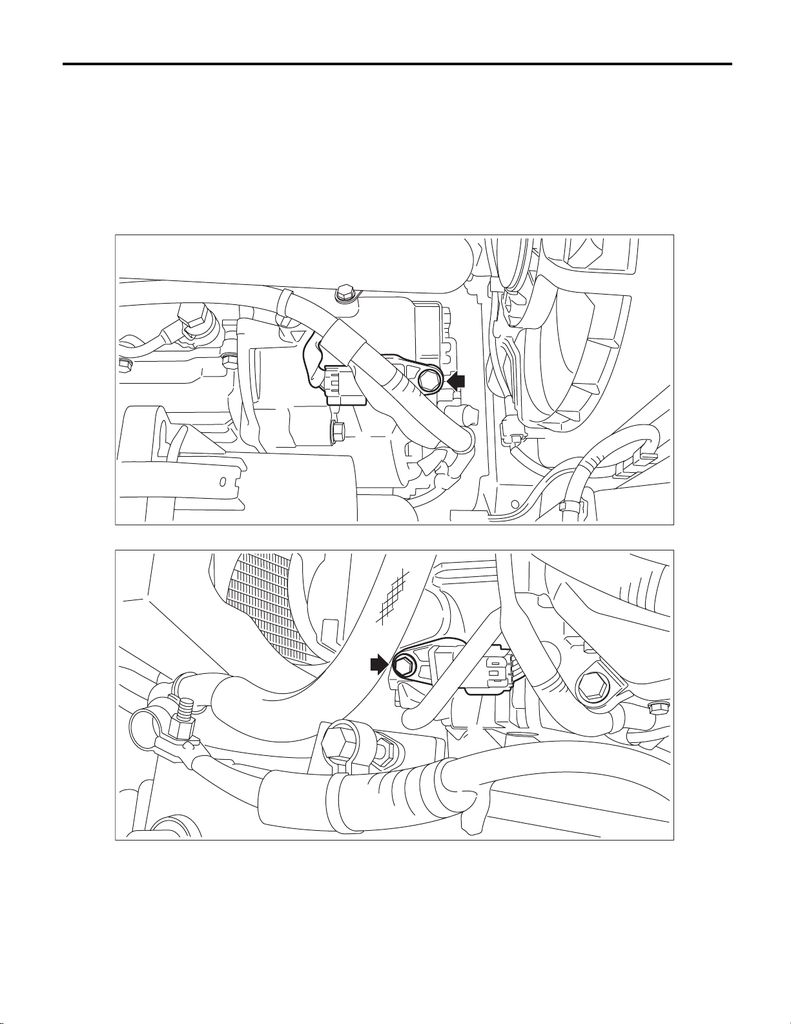

FU(w/o STI)-103

Camshaft Position Sensor

FUEL INJECTION (FUEL SYSTEMS)

15.Camshaft Position Sensor

A: REMOVAL

1. INTAKE SIDE

1) Disconnect the ground terminal from battery sensor. <Ref. to NT-5, BATTERY, NOTE, Note.>

2) Remove the air intake duct. (RH side only) <Ref. to IN(w/o STI)-22, REMOVAL, Air Intake Duct.>

3) Disconnect the connector (A) from the camshaft position sensor, and remove the camshaft position sensor

from the chain cover.

• RH side

•LH side

FU-07208

(A)

FU-07209

(A)

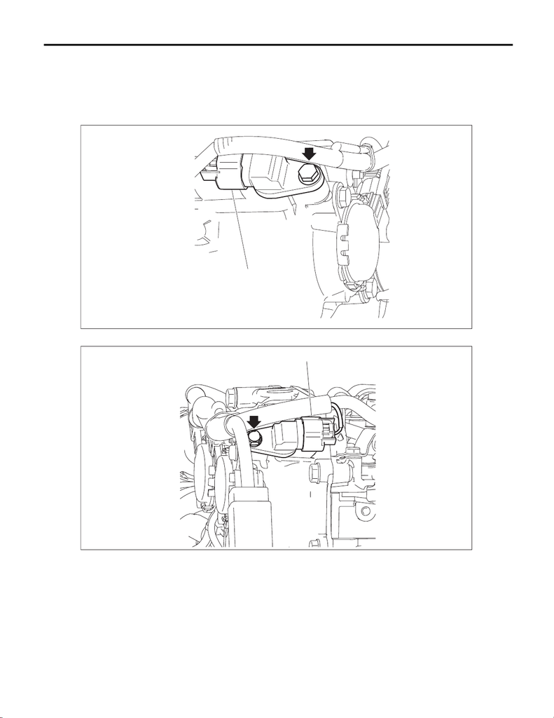

FU(w/o STI)-104

Camshaft Position Sensor

FUEL INJECTION (FUEL SYSTEMS)

2. EXHAUST SIDE

1) Disconnect the ground terminal from battery sensor. <Ref. to NT-5, BATTERY, NOTE, Note.>

2) Remove the under cover. <Ref. to EI-21, REMOVAL, Front Under Cover.>

3) Disconnect the connector (A) from the camshaft position sensor, and remove the camshaft position sensor

from the chain cover.

• RH side

•LH side

B: INSTALLATION

Install in the reverse order of removal.

NOTE:

• Use new O-rings.

• Apply engine oil to O-ring.

Tightening torque:

6.4 N·m (0.7 kgf-m, 4.7 ft-lb)

FU-08369

(A)

FU-08370

(A)

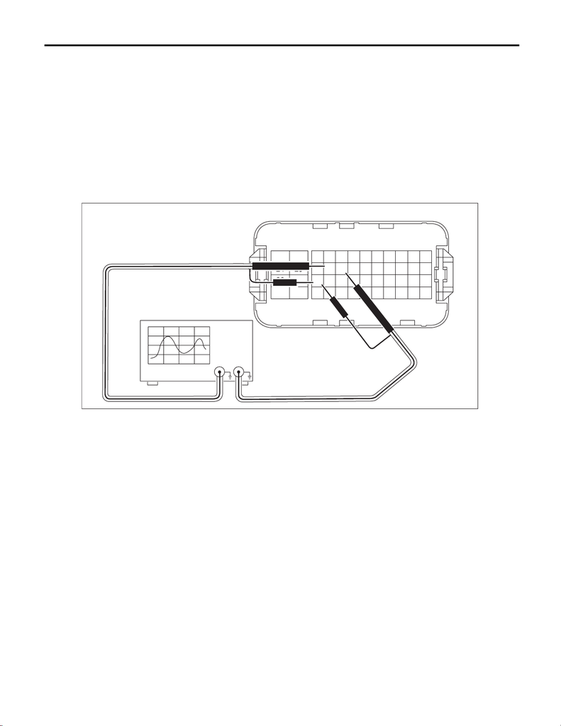

FU(w/o STI)-105

Camshaft Position Sensor

FUEL INJECTION (FUEL SYSTEMS)

C: INSPECTION

1. CAMSHAFT POSITION SENSOR (METHOD WITH OSCILLOSCOPE)

1) Disconnect the ground terminal from battery sensor. <Ref. to NT-5, BATTERY, NOTE, Note.>

2) Prepare an oscilloscope.

3) Remove the engine control module (ECM). <Ref. to FU(w/o STI)-132, REMOVAL, Engine Control Module

(ECM).>

4) Install the ST between the ECM and bulkhead harness and the engine harness. <Ref. to EN(w/o STI)(di-

ag)-6, CAUTION, General Description.>

ST 18460AA030 CHECK BOARD

5) Connect the ground terminal to battery sensor. <Ref. to NT-5, BATTERY, NOTE, Note.>

6) Connect the probe to ST.

• Intake camshaft position sensor

(A) To the check board connector

(ECM connector)

FU-07518

(A)

7

9

10

8

5

23

1112

6

19

21

22

20

17

24

3536

4748

18

31

33

34

32

2930

43

45

46

44

4142

3

4

12

15

16

1314

27

28

2526

39

40

3738

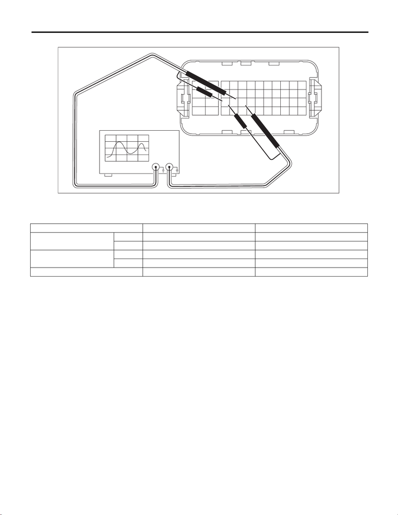

FU(w/o STI)-106

Camshaft Position Sensor

FUEL INJECTION (FUEL SYSTEMS)

• Exhaust camshaft position sensor

7) Start the engine and let it idle.

(A) To the check board connector

(ECM connector)

Camshaft position sensor Terminal No. Probe

Intake

RH 20 +

LH 21 +

Exhaust

RH 32 +

LH 33 +

RH and LH 34 –

FU-07924

(A)

7

9

10

8

5

23

1112

6

19

21

22

20

17

24

3536

4748

18

31

33

34

32

2930

43

45

46

44

4142

3

4

12

15

16

1314

27

28

2526

39

40

3738

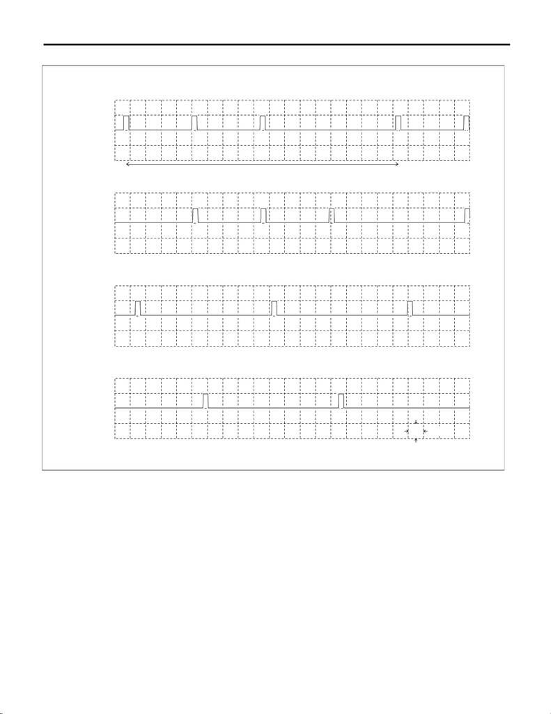

FU(w/o STI)-107

Camshaft Position Sensor

FUEL INJECTION (FUEL SYSTEMS)

8) Check the pattern is the same as the waveform and voltage shown below.

9) After inspection, install the related parts in the reverse order of removal.

2. OTHER INSPECTIONS

Check that the camshaft position sensor has no deformation, cracks or other damages.

(A) One camshaft rotation (C) Intake camshaft position sensor

LH

(E) Exhaust camshaft position sensor

LH

(B) Intake camshaft position sensor

RH

(D) Exhaust camshaft position sensor

RH

FU-07925

0

0

5V

10ms

0

0

(A)

(B)

(C)

(D)

(E)